# Actividad2.4

Cesar Vazquez

2022-12-01

```r
library(MASS)
library(ggplot2)
library(klaR)
```

```r
M <- read.csv("BD_Character.csv")
head(M)
```

```
##   edad semanas peso talla glucosa presion grupo
## 1   42      29  9.7    32     1.9      37     1
## 2   58      43  9.0    37     2.5      38     0
## 3   59      41  8.2    44     1.5      23     1
## 4   64      46  7.5    49     1.4      26     1
## 5   67      49  6.8    54     1.8      31     1
## 6   52      39  5.3    51     1.4     317     0
```

## 0.- Designa a la variable “Grupo” como variable dependiente y acota tu base de datos.

```r
M$grupo <- factor(M$grupo, levels = c(1,0), labels = c("Si", "No"))
head(M)
```

```
##   edad semanas peso talla glucosa presion grupo
## 1   42      29  9.7    32     1.9      37    Si
## 2   58      43  9.0    37     2.5      38    No
## 3   59      41  8.2    44     1.5      23    Si
## 4   64      46  7.5    49     1.4      26    Si
## 5   67      49  6.8    54     1.8      31    Si
## 6   52      39  5.3    51     1.4     317    No
```

##1.- Determina los siguientes puntos de toda la base de datos (variables cuantitativas):

**a)** La matriz de varianzas y covarianzas

```r
mcov <- cov(M[, -c(7)])
mcov
```

```
##               edad     semanas        peso       talla   glucosa     presion
## edad     581.71897  216.572389   15.221200 -139.839606 -2.327930  -256.36700
## semanas  216.57239  148.291868    9.553010  -55.449823 -3.722298  -252.19516
## peso      15.22120    9.553010   18.914113  -56.881020  1.615497  -169.61749
## talla   -139.83961  -55.449823  -56.881020  410.585929 -4.009348   616.87497
## glucosa   -2.32793   -3.722298    1.615497   -4.009348  1.363426    13.07486
## presion -256.36700 -252.195164 -169.617490  616.874975 13.074865 20549.20297
```

**b)** La matriz de correlación

```r
mCor <- cor(M[, -c(7)])
mCor
```

```
##                edad    semanas       peso      talla     glucosa     presion
## edad     1.00000000  0.7373740  0.1451106 -0.2861354 -0.08266042 -0.07414946
## semanas  0.73737397  1.0000000  0.1803801 -0.2247188 -0.26178016 -0.14447097
## peso     0.14511065  0.1803801  1.0000000 -0.6454645  0.31812480 -0.27206968
## talla   -0.28613537 -0.2247188 -0.6454645  1.0000000 -0.16945560  0.21237218
## glucosa -0.08266042 -0.2617802  0.3181248 -0.1694556  1.00000000  0.07811311
## presion -0.07414946 -0.1444710 -0.2720697  0.2123722  0.07811311  1.00000000
```

## 2.- Realiza un análisis discriminante para responder las siguientes preguntas:

**a)** Obtenga la media para cada variable predictora en función del grupo (puede utilizar la función tapply)

```r
tapply(M$edad, M$grupo, mean)
```

```
##       Si       No
## 41.88133 42.53681
```

```r
tapply(M$semanas, M$grupo, mean)
```

```
##       Si       No
## 21.21054 21.25246
```

```r
tapply(M$peso, M$grupo, mean)
```

```
##       Si       No
## 17.27006 17.26092
```

```r
tapply(M$talla, M$grupo, mean)
```

```
##       Si       No
## 48.32590 48.10104
```

```r
tapply(M$glucosa, M$grupo, mean)
```

```
##       Si       No
## 2.508404 2.446021
```

```r
tapply(M$presion, M$grupo, mean)
```

```
##       Si       No
## 237.6500 235.3717
```

**b)** Utilice algún criterio para la selección de variables a utilizar en el modelo

Criterio de lambda de Wilks para selección de variables

```r
greedy.wilks(grupo ~., M)
```

```
## Formula containing included variables:
##
## grupo ~ glucosa
## <environment: 0x7f96bd761a90>
##
##
## Values calculated in each step of the selection procedure:
##
##      vars Wilks.lambda F.statistics.overall p.value.overall F.statistics.diff
## 1 glucosa    0.9992863             4.765647      0.02906788          4.765647
##   p.value.diff
## 1   0.02906788
```

**c)** Muestre la distribución de datos en función de la variable dependiente (utilice la función prop.table(table())

```r
prop.table(table(M$grupo))
```

```
##
##        Si        No
## 0.4973783 0.5026217
```

**d)** Calcule la(s) funcion(es) lineal(es) discriminante(s) para un análisis discriminante.

```r
model <- lda(grupo ~ glucosa , data = M)
model
```

```
## Call:
## lda(grupo ~ glucosa, data = M)
##
## Prior probabilities of groups:
##        Si        No
## 0.4973783 0.5026217
##
## Group means:
##     glucosa
## Si 2.508404
## No 2.446021
##
## Coefficients of linear discriminants:
##               LD1
## glucosa 0.8566565
```

**e)** Estime los valores de la función discriminante utilizando los coeficientes del modelo en las variables seleccionadas.

```r
model$scaling
```

```
##               LD1
## glucosa 0.8566565
```

Debido a que el modelo solo utiliza la glucosa como variable predictora, el coeficiente de la función discriminante es 0.8566565.

**f)** Realice predicciones del modelo

```r
predictions <- predict(model, M)
predictions
```

[output not shown]

[output cut: 13622 more lines]

**g) ¿Se logró segmentar?**

```r
c1 = (sum(tapply(model$scaling[1]*M$glucosa, M$grupo, mean))) /2
c1
```

```
## [1] 2.12212
```

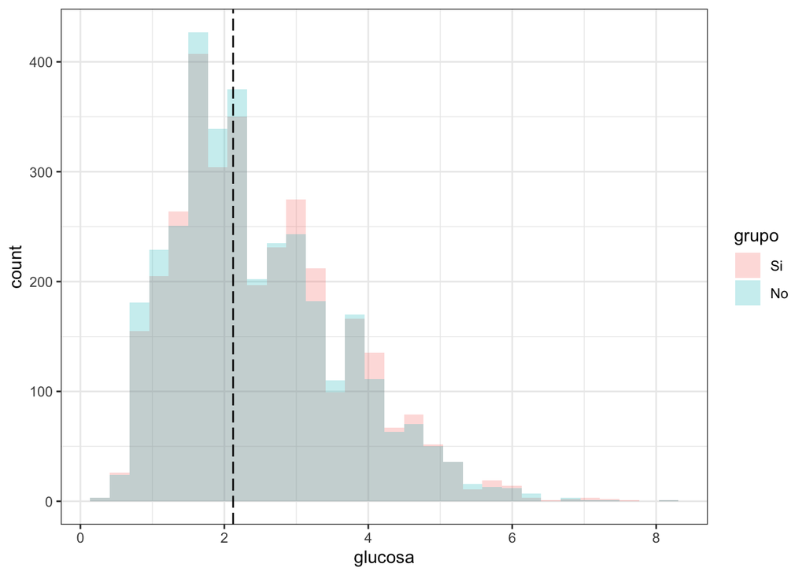

```r
ggplot(M) +
  aes(x  = glucosa, fill = grupo) +
  geom_histogram(alpha = 0.25, position = "identity") +
  theme_bw() +
  geom_vline(xintercept = c1, linetype = "longdash")
```

A partir de la visualización de la gráfica utilizando el criterio de separación $C_1$ los datos no se observan segmentados ya que los grupos están traslapados entre sí, lo cual nos dice que clasificación no se logro segmentar.

**h)** ¿Qué variable o variables discriminan mejor?

A partir del criterio de wills, la variable que discrimina mejor es la de la glucosa.

**i)** ¿El modelo es bueno para pronosticar?

Al no poder realizar una clasificación se concluye que el modelo no es bueno para la realización de pronosticos.